# Homework 6 - Jacob Igel

Last complied on April 13, 2023

1. Refer to the CarsData.csv used in the notes. Suppose each observation costs $10,000. How much did the Latin Squares Design without replication cost? How much did the Latin Squares design with replication cost? How much would a completely randomized design (CRD) cost?
- Without replication cost: (9*10000) = $90,000
- With replication cost: (18*10000) = $180,000
- CRD Cost: (3*3*3)*10000 = $270,000 –> FUEL TYPE, CAR TYPE, SPEED = 3* 3 * 3

A company wishes to test the market for a new snack. Two factors are of interest: the advertising campaign and the product description on the package. Four types of campaigns are considered, and four different descriptions are considered. The various test campaigns were conducted in four cities, 1, 2, 3, and 4. Sales in thousands of dollars were recorded. See page 187 in your test for a description of the factor levels. The data is contained in the “snacks.csv” file. Note, the most common use of an LSD is with two blocking factors, but this does not necessarily have to be the case.

```r
snacks <- read.csv("/Users/jacobigel/Desktop/School/ISA365-A/Datasets/snacks.csv", stringsAsFactors = TRUE)

snacks$City <- as.factor(snacks$City)


snacks
```

```
##    Campaign City Description Sales
## 1         I    1           A    42
## 2         I    2           B    61
## 3         I    3           C    65
## 4         I    4           D    66
## 5        II    1           B    60
## 6        II    2           C    55
## 7        II    3           D    59
## 8        II    4           A    61
## 9       III    1           C    49
## 10      III    2           D    51
## 11      III    3           A    47
## 12      III    4           B    49
## 13       IV    1           D    53
## 14       IV    2           A    51
## 15       IV    3           B    52
## 16       IV    4           C    52
```

2. What type of design is this?
- Latin Square Design
3. What are the factor(s)?
- The type of advertising campaign
- The product description
4. What are the blocking factor(s)?
- City
5. Visualize the results of this design.

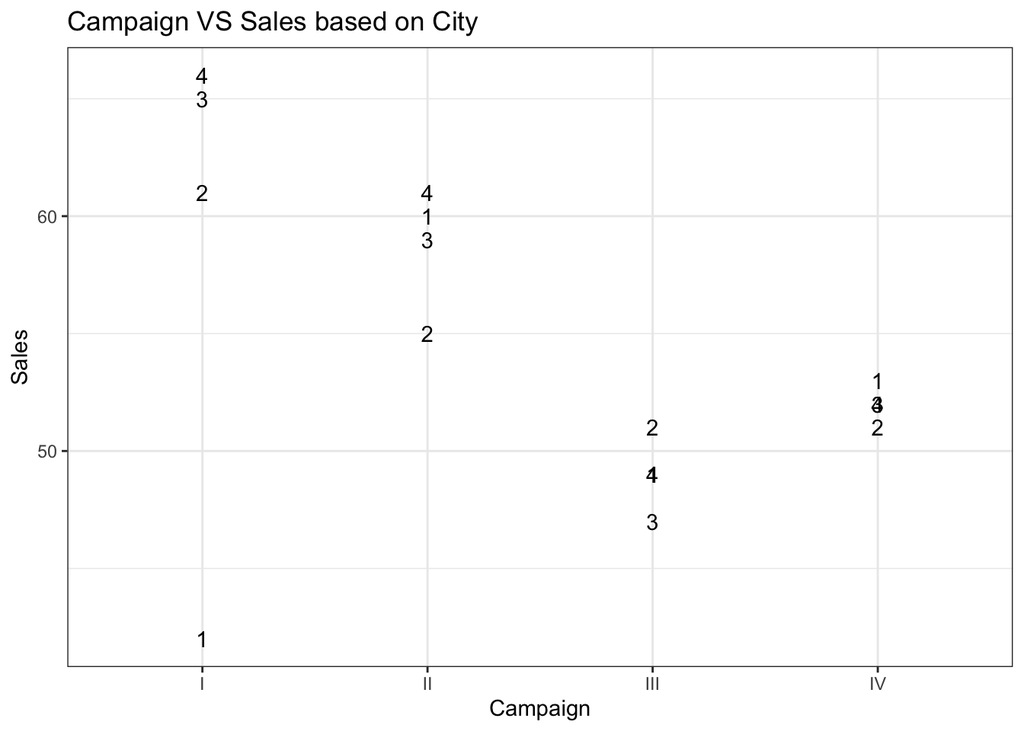

```r
ggplot(snacks, aes(x=Campaign, y=Sales, group=City))+geom_text(aes(label=City))+theme_bw()+ggtitle("Campaign VS Sales based on City")
```

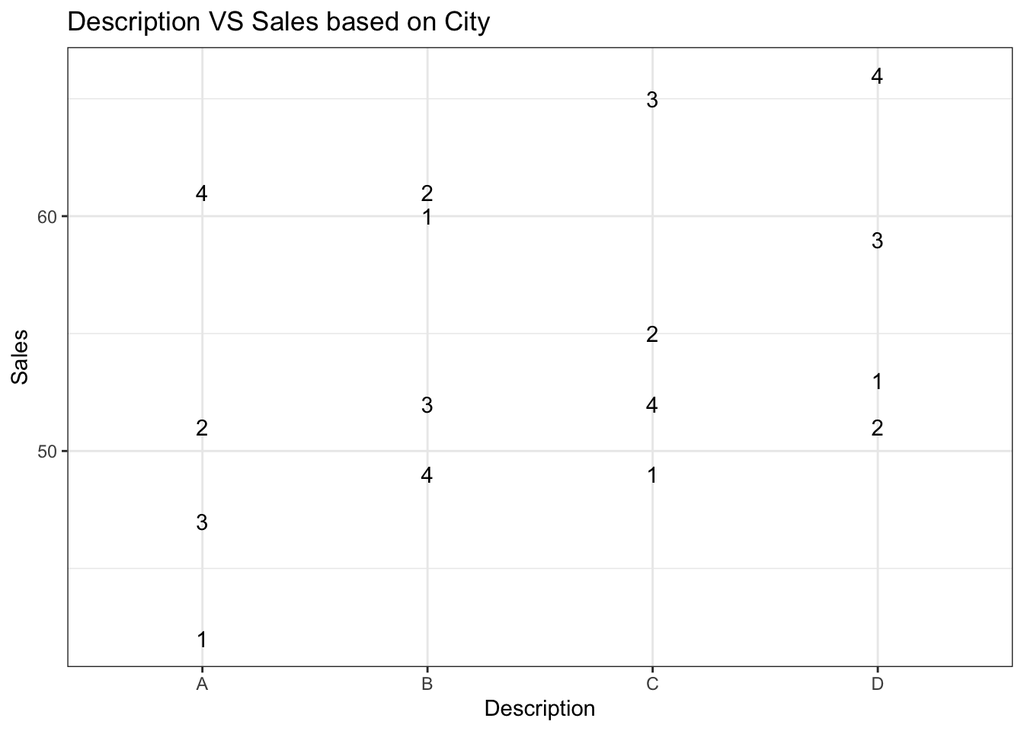

```r
ggplot(snacks, aes(x=Description, y=Sales, group=City))+geom_text(aes(label=City))+theme_bw()+ggtitle("Description VS Sales based on City")
```

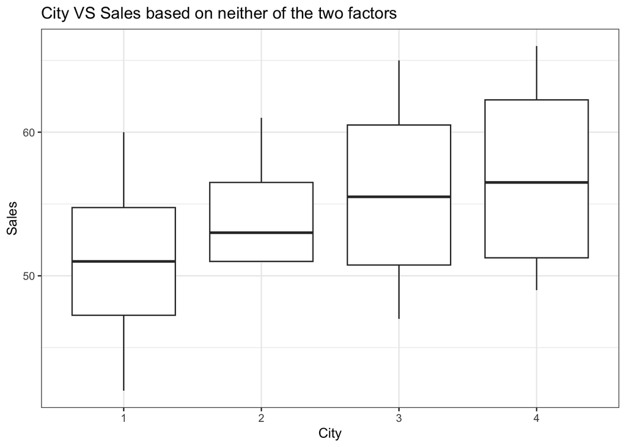

```r
ggplot(snacks, aes(x=City, y=Sales))+geom_boxplot()+theme_bw()+ggtitle("City VS Sales based on neither of the two factors")
```

```r
# Facet grid
```

6. Run the appropriate analysis for this design and write your conclusion in terms of the problem. Make sure the degrees of freedom are correct!

```r
mod1<-aov(Sales~Campaign+City+Description, data=snacks)
summary(mod1)
```

```
##             Df Sum Sq Mean Sq F value Pr(>F)
## Campaign     3 282.19   94.06   2.579  0.149
## City         3  80.19   26.73   0.733  0.569
## Description  3 108.69   36.23   0.993  0.457
## Residuals    6 218.88   36.48
```

7. Check the appropriate assumptions for your analysis in number 6.

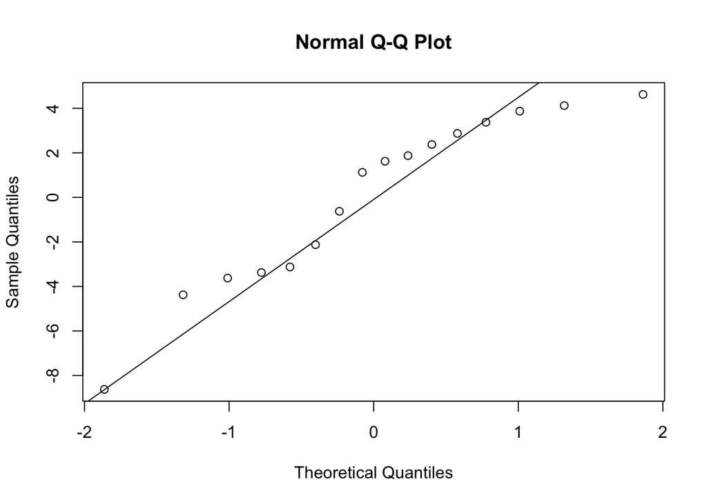

```r
qqnorm(mod1$residuals)
qqline(mod1$residuals)
```

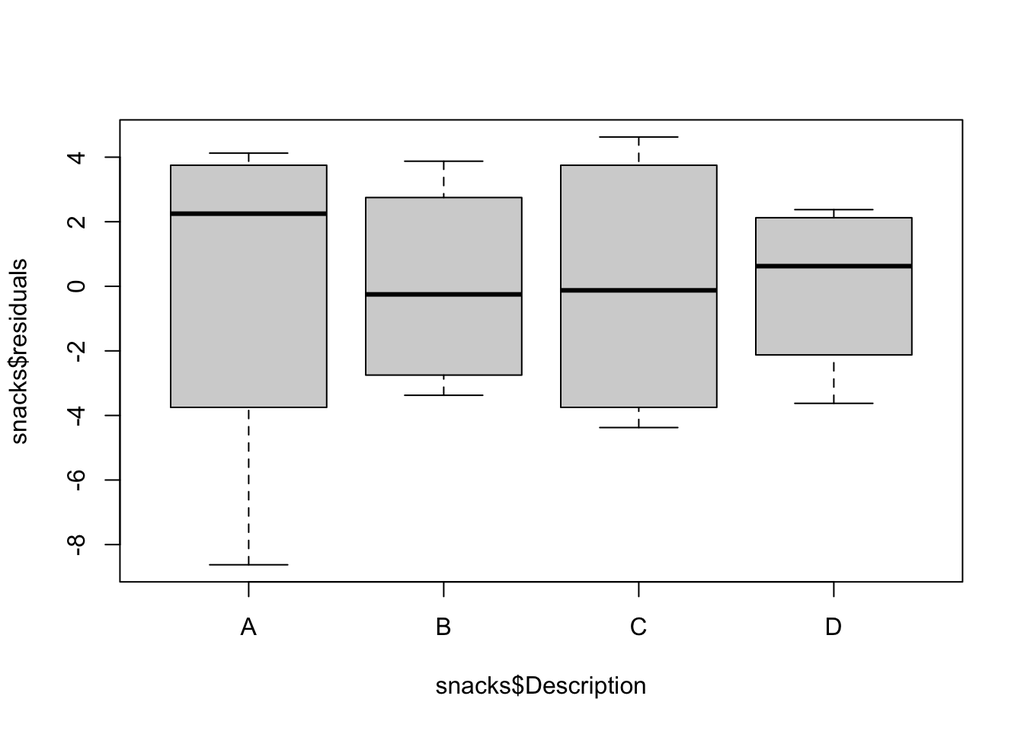

```r
snacks$residuals<-mod1$residuals

boxplot(snacks$residuals~snacks$Description)
```

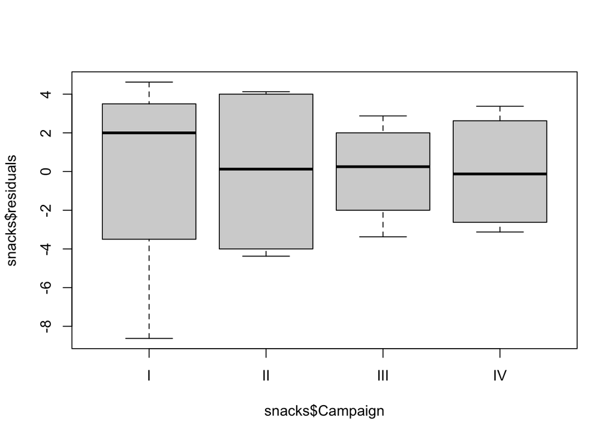

```r
boxplot(snacks$residuals~snacks$Campaign)
```

Miami is running an experiment attempting to entice more students to eat on campus. They sent out mailers with a different offer to students. One offer was “bring a friend for free” another was “take a to-go bag” and lastly “50% off one meal”.They measured the spend on campus dining for each offer. The data is contained in the file “miami.csv”.

```r
miami <- read.csv("/Users/jacobigel/Desktop/School/ISA365-A/Datasets/miami.csv", stringsAsFactors = TRUE)

head(miami,20)
```

```
##       Friend     Togo  PerctOff         Year
## 1  10.544316 11.57774  7.034873   Third Year
## 2   5.886692  0.00000 10.714189   First Year
## 3   0.000000  0.00000  0.000000 Fourth Year+
## 4  10.252111  0.00000  0.000000   Third Year
## 5   8.604295 11.74287  7.870956   Third Year
## 6   6.361674  0.00000  9.600828   First Year
## 7   0.000000  0.00000  6.089518 Fourth Year+
## 8  14.093733 14.36214  6.141795   First Year
## 9   7.825124  0.00000  0.000000 Fourth Year+
## 10  8.168935  0.00000  6.783824  Second Year
## 11  0.000000 14.21003  0.000000  Second Year
## 12  8.050970 14.70466  6.242434   First Year
## 13  6.372552  0.00000  0.000000 Fourth Year+
## 14 10.784492  0.00000  0.000000   First Year
## 15  6.200617 12.47158  0.000000  Second Year
## 16 12.681117 12.91093  0.000000  Second Year
## 17  8.579349  0.00000  9.729572  Second Year
## 18  6.428572  0.00000 10.835158   First Year
## 19  9.968085  0.00000  0.000000   First Year
## 20  8.487362 14.39994  7.612205  Second Year
```

8. Visualize the results of the experiment. Make sure you get the order correct on a graph.

```r
miami_long <- miami %>% pivot_longer(
  c("Friend", "Togo", "PerctOff"),
  names_to = "Treatment",
  values_to = "Data"
)

miami_long$Treatment <- as.factor(miami_long$Treatment)
head(miami_long,20)
```

```
## # A tibble: 20 × 3
##    Year         Treatment  Data
##    <fct>        <fct>     <dbl>
##  1 Third Year   Friend    10.5
##  2 Third Year   Togo      11.6
##  3 Third Year   PerctOff   7.03
##  4 First Year   Friend     5.89
##  5 First Year   Togo       0
##  6 First Year   PerctOff  10.7
##  7 Fourth Year+ Friend     0
##  8 Fourth Year+ Togo       0
##  9 Fourth Year+ PerctOff   0
## 10 Third Year   Friend    10.3
## 11 Third Year   Togo       0
## 12 Third Year   PerctOff   0
## 13 Third Year   Friend     8.60
## 14 Third Year   Togo      11.7
## 15 Third Year   PerctOff   7.87
## 16 First Year   Friend     6.36
## 17 First Year   Togo       0
## 18 First Year   PerctOff   9.60
## 19 Fourth Year+ Friend     0
## 20 Fourth Year+ Togo       0
```

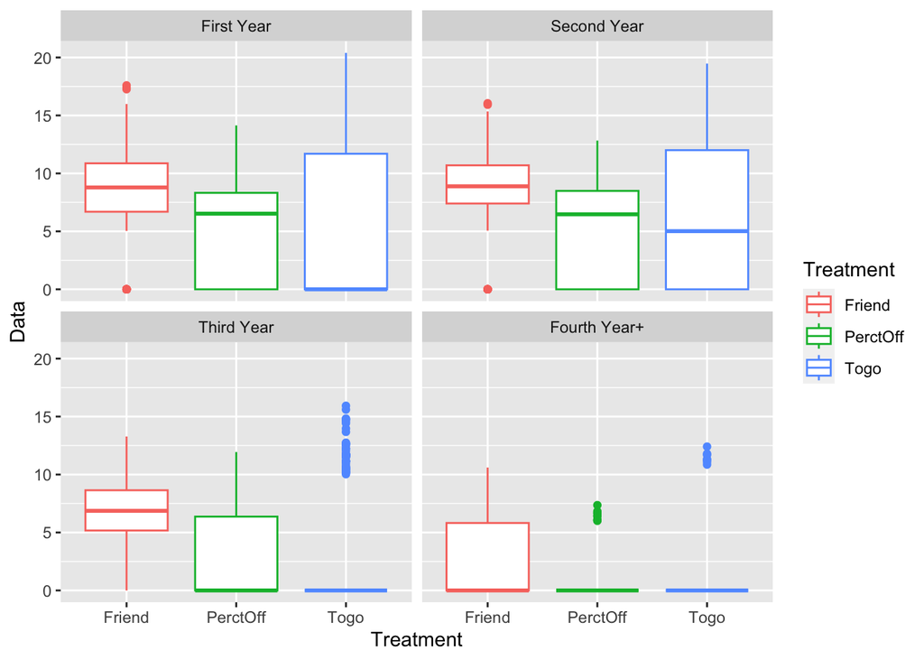

```r
miami_long$Year<-factor(miami_long$Year, levels=c("First Year", "Second Year", "Third Year", "Fourth Year+"))

ggplot(miami_long, aes(x=Treatment, y=Data, color = Treatment)) + geom_boxplot() + facet_wrap(~ Year)
```

9. Analyze the experiment.

```r
mod2<-aov(Data~Treatment + Year, data=miami_long)
summary(mod2)
```

```
##               Df Sum Sq Mean Sq F value Pr(>F)
## Treatment      2   5344    2672   148.3 <2e-16 ***
## Year           3  12295    4098   227.5 <2e-16 ***
## Residuals   2394  43132      18
## ---
## Signif. codes:  0 '***' 0.001 '**' 0.01 '*' 0.05 '.' 0.1 ' ' 1
```

10. Write your conclusions below.
- We can conclude that since the degrees of freedom is adding up to what its suppose to (2,399) that we ran the mod on the correct data set and that we can use the visualization for the rest.
- For first and second year students, since they are living on campus, they are using a significant of the deals more than the upperclassmen. That is probably from them living on campus in close proximity to dining halls.
- We can see that the trend we were seeing with first and second year students is falling; third year students have a lower average use of all three, especially with Togo with a stark differnce from zero to ten.
- Lastly, Fourth year students and up mostly do not use these deals but if they do, its more likely to be with a friend than use either of the two other deals.
11. Kroger is testing out different produce layouts in it’s 5 pre-designated testing stores. These stores are chosen based on the the demographics of their customers. They will test layouts produce configurations 1-5 during 5 months of testing. Produce an appropriate design for this scenario and show it below. Make sure the treatments are in a random order.

```r
library(agricolae)

store <-c("1","2","3","4","5")
outdesign<-design.lsd(store, seed=45, randomization = TRUE) #creates design and lists a bunch of properties
lsd<-outdesign$book #outdesign$book is the actual design matrix from our "outdesign" object
levels(lsd$row)<-c("Month 1", "Month 2", "Month 3", "Month 4", "Month 5") #relabel the rows
levels(lsd$col)<-c("Layout 1", "Layout 2", "Layout 3", "Layout 4", "Layout 5") #relabel the columns
lsd  #notice everything is coded correctly
```

```
##    plots     row      col store
## 1    101 Month 1 Layout 1     3
## 2    102 Month 1 Layout 2     4
## 3    103 Month 1 Layout 3     2
## 4    104 Month 1 Layout 4     5
## 5    105 Month 1 Layout 5     1
## 6    201 Month 2 Layout 1     1
## 7    202 Month 2 Layout 2     2
## 8    203 Month 2 Layout 3     5
## 9    204 Month 2 Layout 4     3
## 10   205 Month 2 Layout 5     4
## 11   301 Month 3 Layout 1     4
## 12   302 Month 3 Layout 2     5
## 13   303 Month 3 Layout 3     3
## 14   304 Month 3 Layout 4     1
## 15   305 Month 3 Layout 5     2
## 16   401 Month 4 Layout 1     2
## 17   402 Month 4 Layout 2     3
## 18   403 Month 4 Layout 3     1
## 19   404 Month 4 Layout 4     4
## 20   405 Month 4 Layout 5     5
## 21   501 Month 5 Layout 1     5
## 22   502 Month 5 Layout 2     1
## 23   503 Month 5 Layout 3     4
## 24   504 Month 5 Layout 4     2
## 25   505 Month 5 Layout 5     3
```

```r
lsd$y<-rnorm(25, mean=25, sd=5) # simulating a "y"
lsd$row <- as.factor(lsd$row)
lsd$col <- as.factor(lsd$col)
lsd$store <- as.factor(lsd$store)

mod3<-aov(y~row+col+store, data=lsd)
summary(mod3)
```

```
##             Df Sum Sq Mean Sq F value Pr(>F)
## row          4  51.07   12.77   0.730  0.589
## col          4  51.67   12.92   0.738  0.584
## store        4 136.22   34.06   1.947  0.167
## Residuals   12 209.91   17.49
```

12. For the design in question 11 list out the degrees of freedom for the following:
- Produce Configuration: 4
- Store: 4
- Month: 4
- Error: 12
- Total: 24

Airbnb ran a test varying the ways that customers explore listing. This test involved changing more than one factor at at time. See the image below. They tested two factors Background and the entry button for the exploration. They set each of these factors at two levels: Lake=-1 and Woods=1 for Background and Get Inspired=-1 and I’m Flexible=+1 for the button.

[figure not shown]

13. What type of experiment is this? What is the advantage to running this type of experiment as opposed to just an A/B test?
- This experiment is a 2^2 factorial design since the two factors (background and button) have two levels each
- A factorial design allows for testing multiple factors simultaneously as well as the interaction between them.
- A/B tests typically test only one factor at a time, making it difficult to determine how different factors interact.
14. The data is contained in the file “airbnb.csv”. Read in the data and transform the variables for the proper analysis.

```r
bnb <- read.csv("/Users/jacobigel/Desktop/School/ISA365-A/Datasets/airbnb.csv", stringsAsFactors = TRUE)

head(bnb, 20)
```

```
##    Background   Button Bookings
## 1       Woods Inspired        5
## 2        Lake Flexible       10
## 3        Lake Inspired        9
## 4       Woods Flexible        5
## 5       Woods Inspired        8
## 6        Lake Flexible       10
## 7       Woods Flexible        8
## 8        Lake Inspired        6
## 9        Lake Inspired        6
## 10       Lake Flexible        7
## 11      Woods Flexible        8
## 12      Woods Inspired        6
## 13       Lake Inspired        6
## 14      Woods Inspired        6
## 15      Woods Flexible       14
## 16       Lake Flexible       11
## 17      Woods Inspired        7
## 18      Woods Flexible       12
## 19       Lake Flexible        7
## 20       Lake Inspired        7
```

15. Is this design replicated?
- Yes!
16. Conduce the appropriate analysis of the experiment.

```r
bnb$Background <- ifelse(bnb$Background == "Woods", 1, -1)
bnb$Button <- ifelse(bnb$Button == "Flexible", 1, -1)

mod4<-lm(Bookings~(Background+Button)^2, data=bnb)
summary(mod4)
```

```
##
## Call:
## lm(formula = Bookings ~ (Background + Button)^2, data = bnb)
##
## Residuals:
##     Min      1Q  Median      3Q     Max
## -4.4903 -2.4664 -0.4903  1.5336 15.7047
##
## Coefficients:
##                    Estimate Std. Error t value Pr(>|t|)
## (Intercept)       8.4789650  0.0164232 516.281  < 2e-16 ***
## Background        0.0861719  0.0164232   5.247 1.56e-07 ***
## Button            0.0006573  0.0164232   0.040    0.968
## Background:Button 0.0981236  0.0164232   5.975 2.33e-09 ***
## ---
## Signif. codes:  0 '***' 0.001 '**' 0.01 '*' 0.05 '.' 0.1 ' ' 1
##
## Residual standard error: 3.004 on 33464 degrees of freedom
## Multiple R-squared:  0.001886,   Adjusted R-squared:  0.001796
## F-statistic: 21.08 on 3 and 33464 DF,  p-value: 1.235e-13
```

17. Calculate the effect for the background factor. Interpret the effect.

```r
coefficients <- coef(mod4)
coefficients
```

```
##       (Intercept)        Background            Button Background:Button
##      8.4789649815      0.0861718657      0.0006573443      0.0981235807
```

- The effect of the background factor has a estimated slope of 0.086, making it more likely to influence the amount of bookings there are instead of button type.
18. If appropriate, produce an interaction plot for the model you created in question 16.

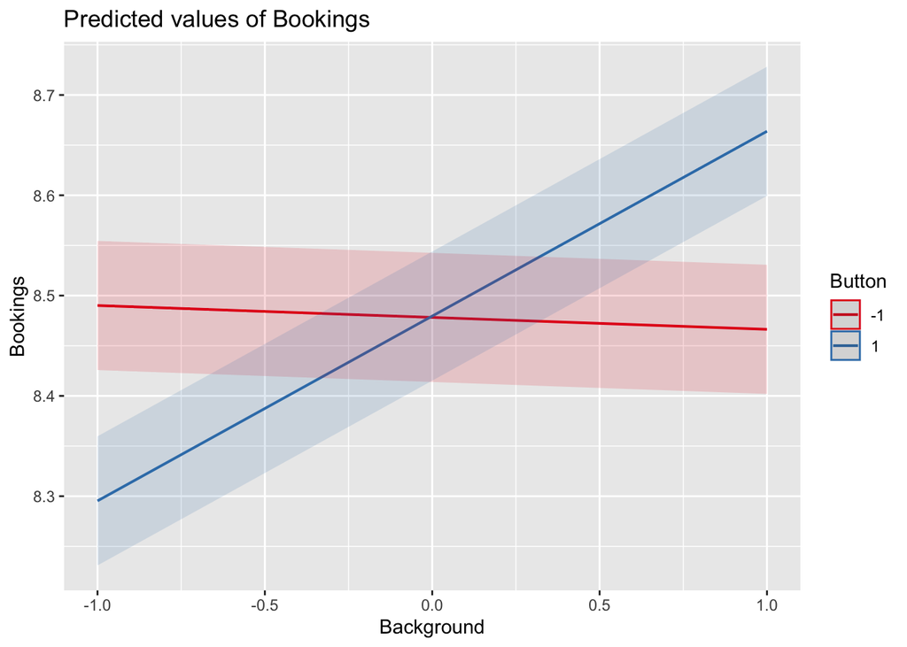

```r
library(sjPlot)
plot_model(mod4, type=c("int"))
```

19. What page should AirBnb consider using to maximize bookings?
- Background: +1
- Button: +1
- AirBnb should consider using the Woods background with the Flexible button to maximize bookings